# Estudo Dirigido - Computer Hardware

Ítalo Gonçalves e José Antonio

2024-10-06

## Sobre a base de dados

O domínio do problema é a Ciência da Computação, focando no desempenho de hardware de computadores. O conhecimento esperado envolve dados de desempenho relativo da CPU, descritos em termos de tempo de ciclo, tamanho de memória, etc.

```r
# C:/Users/2019101100910126/Documents/Github/EstudoDirigindo-MinecaoDeDados/Computer Hardware/computer+hardware/machine.data
computer_data <- read.table("C:/Users/josej/OneDrive/Documentos/GitHub/EstudoDirigindo-MinecaoDeDados/Computer Hardware/computer+hardware/machine.data", header=FALSE, sep=",")
colnames(computer_data) <- c("VendorName", "ModelName", "MYCT", "MMIN", "MMAX", "CACH", "CHMIN", "CHMAX", "PRP", "ERP")
View(computer_data)
```

## Dimensionalidade dos Dados

Aqui, utilizamos as funções `dim()`, `nrow()` e `ncol()` temos o numero de amostra de 209 e o numero de variaveis de 10

```r
print(paste('Número de linhas(amostras):', nrow(computer_data)))
```

```
## [1] "Número de linhas(amostras): 209"
```

```r
print(paste('Número de colunas(variaveis):', ncol(computer_data)))
```

```
## [1] "Número de colunas(variaveis): 10"
```

## Análise Estrutural das Variáveis

Utilizamos a função `str()` para exibir a estrutura do conjunto de dados.

```r
# Exibir a estrutura do dataset
str(computer_data)
```

```
## 'data.frame':    209 obs. of  10 variables:
##  $ VendorName: chr  "adviser" "amdahl" "amdahl" "amdahl" ...
##  $ ModelName : chr  "32/60" "470v/7" "470v/7a" "470v/7b" ...
##  $ MYCT      : int  125 29 29 29 29 26 23 23 23 23 ...
##  $ MMIN      : int  256 8000 8000 8000 8000 8000 16000 16000 16000 32000 ...
##  $ MMAX      : int  6000 32000 32000 32000 16000 32000 32000 32000 64000 64000 ...
##  $ CACH      : int  256 32 32 32 32 64 64 64 64 128 ...
##  $ CHMIN     : int  16 8 8 8 8 8 16 16 16 32 ...
##  $ CHMAX     : int  128 32 32 32 16 32 32 32 32 64 ...
##  $ PRP       : int  198 269 220 172 132 318 367 489 636 1144 ...
##  $ ERP       : int  199 253 253 253 132 290 381 381 749 1238 ...
```

A maioria dos campos vieram com seus datatype certos, menos os dois primeiros, que vieram como chr entao vou fazer a tranformação dele para factor(Variável categórica)

```r
# Transformando colunas de character para factor
computer_data$VendorName <- as.factor(computer_data$VendorName)
computer_data$ModelName <- as.factor(computer_data$ModelName)

# Exibir a estrutura do dataset com as alterações feitas
str(computer_data)
```

```
## 'data.frame':    209 obs. of  10 variables:
##  $ VendorName: Factor w/ 30 levels "adviser","amdahl",..: 1 2 2 2 2 2 2 2 2 2 ...
##  $ ModelName : Factor w/ 209 levels "100","1100/61-h1",..: 30 63 64 65 66 67 75 76 77 78 ...
##  $ MYCT      : int  125 29 29 29 29 26 23 23 23 23 ...
##  $ MMIN      : int  256 8000 8000 8000 8000 8000 16000 16000 16000 32000 ...
##  $ MMAX      : int  6000 32000 32000 32000 16000 32000 32000 32000 64000 64000 ...
##  $ CACH      : int  256 32 32 32 32 64 64 64 64 128 ...
##  $ CHMIN     : int  16 8 8 8 8 8 16 16 16 32 ...
##  $ CHMAX     : int  128 32 32 32 16 32 32 32 32 64 ...
##  $ PRP       : int  198 269 220 172 132 318 367 489 636 1144 ...
##  $ ERP       : int  199 253 253 253 132 290 381 381 749 1238 ...
```

## Integridade da base de dados

Usado a função `summary()` temos resumo estatístico do dataframe, mas para garantir que nao exista valore NA, uma funcao de soma(sum) que vai contar a quantidade de valores NA no dataframe.

```r
# Resumo do dataset
summary(computer_data)
```

```
##      VendorName       ModelName        MYCT             MMIN
##  ibm      : 32   100       :  1   Min.   :  17.0   Min.   :   64
##  nas      : 19   1100/61-h1:  1   1st Qu.:  50.0   1st Qu.:  768
##  honeywell: 13   1100/81   :  1   Median : 110.0   Median : 2000
##  ncr      : 13   1100/82   :  1   Mean   : 203.8   Mean   : 2868
##  sperry   : 13   1100/83   :  1   3rd Qu.: 225.0   3rd Qu.: 4000
##  siemens  : 12   1100/84   :  1   Max.   :1500.0   Max.   :32000
##  (Other)  :107   (Other)   :203
##       MMAX            CACH            CHMIN            CHMAX
##  Min.   :   64   Min.   :  0.00   Min.   : 0.000   Min.   :  0.00
##  1st Qu.: 4000   1st Qu.:  0.00   1st Qu.: 1.000   1st Qu.:  5.00
##  Median : 8000   Median :  8.00   Median : 2.000   Median :  8.00
##  Mean   :11796   Mean   : 25.21   Mean   : 4.699   Mean   : 18.27
##  3rd Qu.:16000   3rd Qu.: 32.00   3rd Qu.: 6.000   3rd Qu.: 24.00
##  Max.   :64000   Max.   :256.00   Max.   :52.000   Max.   :176.00
##
##       PRP              ERP
##  Min.   :   6.0   Min.   :  15.00
##  1st Qu.:  27.0   1st Qu.:  28.00
##  Median :  50.0   Median :  45.00
##  Mean   : 105.6   Mean   :  99.33
##  3rd Qu.: 113.0   3rd Qu.: 101.00
##  Max.   :1150.0   Max.   :1238.00
##
```

```r
# Contar o número total de NAs
quant_na <- sum(is.na(computer_data))

# Exibir o total de NAs
print(paste("Quantidade de dados ausentes(NA):", quant_na))
```

```
## [1] "Quantidade de dados ausentes(NA): 0"
```

## Contagem de amostras

Aqui, fiz uma contagem de amostra para cada classe, primeiro de VendorName e depos de ModelName

### VendorName

Nessa coluna/variavel foi possivel fazer a contagem de amostras sem grandes questoes e foi possivel demostrar as ammostras mais repetivas e seus valores.

```r
# Contar amostras em cada classe
count_VendorName <- table(computer_data$VendorName)

# Criar um data frame organizado
df_porcentagem_VendorName <- data.frame(
  porcentagem = round(((count_VendorName / sum(count_VendorName)) * 100), 2)
)

colnames(df_porcentagem_VendorName) <- c("Amostra", "Porcentagem")

df_porcentagem_VendorName <- df_porcentagem_VendorName %>%
  arrange(desc(Porcentagem))

df_porcentagem_VendorName$Porcentagem <- percent(df_porcentagem_VendorName$Porcentagem / 100)


kable(df_porcentagem_VendorName, caption = "Porcentagem da Classe: Vendor_Name")
```

Porcentagem da Classe: Vendor_Name

| Amostra | Porcentagem |
| --- | --- |
| ibm | 15.31% |
| nas | 9.09% |
| honeywell | 6.22% |
| ncr | 6.22% |
| sperry | 6.22% |
| siemens | 5.74% |
| amdahl | 4.31% |
| cdc | 4.31% |
| burroughs | 3.83% |
| dg | 3.35% |
| harris | 3.35% |
| hp | 3.35% |
| c.r.d | 2.87% |
| dec | 2.87% |
| ipl | 2.87% |
| magnuson | 2.87% |
| cambex | 2.39% |
| formation | 2.39% |
| prime | 2.39% |
| gould | 1.44% |
| nixdorf | 1.44% |
| perkin-elmer | 1.44% |
| apollo | 0.96% |
| basf | 0.96% |
| bti | 0.96% |
| wang | 0.96% |
| adviser | 0.48% |
| four-phase | 0.48% |
| microdata | 0.48% |
| sratus | 0.48% |

### ModelName

Nessa coluna/variavel o nome do medelo nao se repete oque, deixar essa analise de quantidades de valores iguais inutil, já que todos as amostras de campo vão ser unicas para cada resgitros, vou imprimir apenas alguns resgistro para dar de exeplo.

```r
# Contar amostras em cada classe
count_ModelName <- table(computer_data$ModelName)

# Criar um data frame organizado
df_porcentagem_ModelName <- data.frame(
  porcentagem = count_ModelName
)

colnames(df_porcentagem_ModelName) <- c("Amostra", "Contagem")

kable(head(df_porcentagem_ModelName, 20), caption = "Porcentagem da Classe: Model_Name")
```

Porcentagem da Classe: Model_Name

| Amostra | Contagem |
| --- | --- |
| 100 | 1 |
| 1100/61-h1 | 1 |
| 1100/81 | 1 |
| 1100/82 | 1 |
| 1100/83 | 1 |
| 1100/84 | 1 |
| 1100/93 | 1 |
| 1100/94 | 1 |
| 1636-1 | 1 |
| 1636-10 | 1 |
| 1641-1 | 1 |
| 1641-11 | 1 |
| 1651-1 | 1 |
| 2000/260 | 1 |
| 300 | 1 |
| 3000/30 | 1 |
| 3000/40 | 1 |
| 3000/44 | 1 |
| 3000/48 | 1 |
| 3000/64 | 1 |

## Balanceamento dos dados

O balaceamento dos dados podem ser feitos na visao de vendores, assim pensando qual vendendor tem mais amostras e se as amostra entao baleacadas entre vendedores, entao vou pegar todos os vendedores e fazer alguns graficos apenas para deixa mais visual. Existe uma numero muito maior de amostras de vendores maiores.

Pegar o numero de amostra de cada vendendor:

```r
# Contar amostras em cada classe
count_VendorName <- table(computer_data$VendorName)

# Ver as contagens de cada classe
print(count_VendorName)
```

```
##
##      adviser       amdahl       apollo         basf          bti    burroughs
##            1            9            2            2            2            8
##        c.r.d       cambex          cdc          dec           dg    formation
##            6            5            9            6            7            5
##   four-phase        gould       harris    honeywell           hp          ibm
##            1            3            7           13            7           32
##          ipl     magnuson    microdata          nas          ncr      nixdorf
##            6            6            1           19           13            3
## perkin-elmer        prime      siemens       sperry       sratus         wang
##            3            5           12           13            1            2
```

Vou imprimir um grafico em barras para monstrar visualmente a quantidade de amostra para cada vendendor

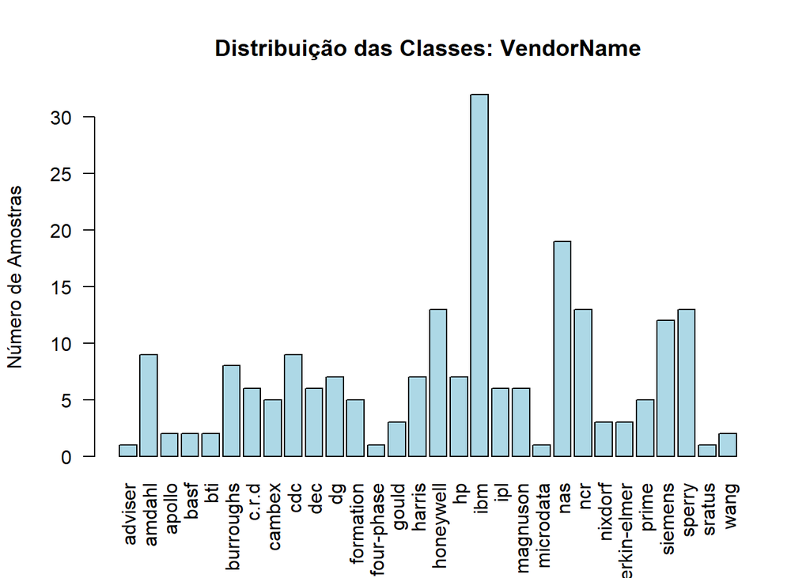

```r
# porcentagem de cada classe
percent_VendorName <- prop.table(count_VendorName) * 100

barplot(count_VendorName, main = "Distribuição das Classes: VendorName", ylab = "Número de Amostras", col = "lightblue", las = 2)

mtext("Classes", side = 1, line = 5)  # line controla a posição vertical do texto
```

O grafico de barras ficou com todos os vendendores entao um grafico em pizza com os com maior numero de registro e todos os restate pode ser mais facil visual como está o balaceamento dos dados.

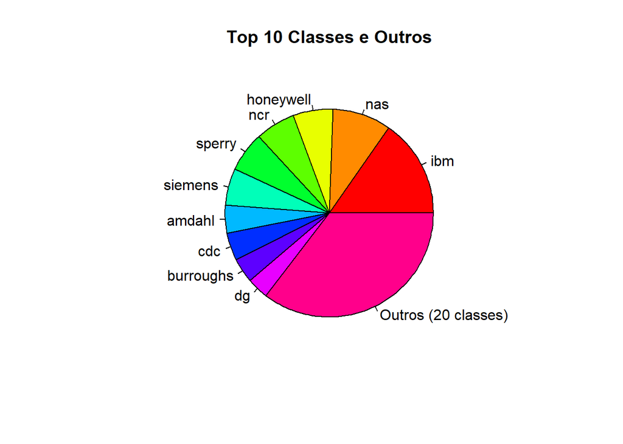

```r
# ---> Grafico Pizza
# Ordenar as classes por tamanho (frequência) em ordem decrescente
sorted_VendorName <- sort(count_VendorName, decreasing = TRUE)

# Selecionar as 10 maiores classes
top_10 <- head(sorted_VendorName, 10)

# Contar o número de classes que estão sendo agrupadas em "Outros"
others_count <- length(tail(sorted_VendorName, length(sorted_VendorName) - 10))

# Combinar as 10 maiores com a soma dos outros
top_10_with_others <- c(top_10, Outros = sum(tail(sorted_VendorName, length(sorted_VendorName) - 10)))

labels <- c(names(top_10), paste("Outros (", others_count, " classes)", sep=""))

pie(top_10_with_others, main = "Top 10 Classes e Outros", col = rainbow(length(top_10_with_others)), labels = labels)
```

## Problemas de Regressão

Para calcular a média e o desvio padrão vou usar as funções mean() e sd(). Vou demosntrar para cada variavel:

#### MYCT

```r
media_MYCT <- mean(computer_data$MYCT)

desvio_padrao_MYCT <- sd(computer_data$MYCT)

print(paste("Média dos valores esperados (MYCT):", round(media_MYCT, 2)))
```

```
## [1] "Média dos valores esperados (MYCT): 203.82"
```

```r
print(paste("Desvio padrão dos valores esperados (MYCT):", round(desvio_padrao_MYCT, 2)))
```

```
## [1] "Desvio padrão dos valores esperados (MYCT): 260.26"
```

#### MMIN

```r
media_MMIN <- mean(computer_data$MMIN)

desvio_padrao_MMIN <- sd(computer_data$MMIN)

print(paste("Média dos valores esperados (MMIN):", round(media_MMIN, 2)))
```

```
## [1] "Média dos valores esperados (MMIN): 2867.98"
```

```r
print(paste("Desvio padrão dos valores esperados (MMIN):", round(desvio_padrao_MMIN, 2)))
```

```
## [1] "Desvio padrão dos valores esperados (MMIN): 3878.74"
```

#### MMAX

```r
media_MMAX <- mean(computer_data$MMAX)

desvio_padrao_MMAX <- sd(computer_data$MMAX)

print(paste("Média dos valores esperados (MMAX):", round(media_MMAX, 2)))
```

```
## [1] "Média dos valores esperados (MMAX): 11796.15"
```

```r
print(paste("Desvio padrão dos valores esperados (MMAX):", round(desvio_padrao_MMAX, 2)))
```

```
## [1] "Desvio padrão dos valores esperados (MMAX): 11726.56"
```

#### CACH

```r
media_CACH <- mean(computer_data$CACH)

desvio_padrao_CACH <- sd(computer_data$CACH)

print(paste("Média dos valores esperados (CACH):", round(media_CACH, 2)))
```

```
## [1] "Média dos valores esperados (CACH): 25.21"
```

```r
print(paste("Desvio padrão dos valores esperados (CACH):", round(desvio_padrao_CACH, 2)))
```

```
## [1] "Desvio padrão dos valores esperados (CACH): 40.63"
```

#### CHMIN

```r
media_CHMIN <- mean(computer_data$CHMIN)

desvio_padrao_CHMIN <- sd(computer_data$CHMIN)

print(paste("Média dos valores esperados (CHMIN):", round(media_CHMIN, 2)))
```

```
## [1] "Média dos valores esperados (CHMIN): 4.7"
```

```r
print(paste("Desvio padrão dos valores esperados (CHMIN):", round(desvio_padrao_CHMIN, 2)))
```

```
## [1] "Desvio padrão dos valores esperados (CHMIN): 6.82"
```

#### CHMAX

```r
media_CHMAX <- mean(computer_data$CHMAX)

desvio_padrao_CHMAX <- sd(computer_data$CHMAX)

print(paste("Média dos valores esperados (CHMAX):", round(media_CHMAX, 2)))
```

```
## [1] "Média dos valores esperados (CHMAX): 18.27"
```

```r
print(paste("Desvio padrão dos valores esperados (CHMAX):", round(desvio_padrao_CHMAX, 2)))
```

```
## [1] "Desvio padrão dos valores esperados (CHMAX): 26"
```

#### PRP

```r
media_PRP <- mean(computer_data$PRP)

desvio_padrao_PRP <- sd(computer_data$PRP)

print(paste("Média dos valores esperados (PRP):", round(media_PRP, 2)))
```

```
## [1] "Média dos valores esperados (PRP): 105.62"
```

```r
print(paste("Desvio padrão dos valores esperados (PRP):", round(desvio_padrao_PRP, 2)))
```

```
## [1] "Desvio padrão dos valores esperados (PRP): 160.83"
```

#### ERP

```r
media_ERP <- mean(computer_data$ERP)

desvio_padrao_ERP <- sd(computer_data$ERP)

print(paste("Média dos valores esperados (ERP):", round(media_ERP, 2)))
```

```
## [1] "Média dos valores esperados (ERP): 99.33"
```

```r
print(paste("Desvio padrão dos valores esperados (ERP):", round(desvio_padrao_ERP, 2)))
```

```
## [1] "Desvio padrão dos valores esperados (ERP): 154.76"
```

## Análise Descritiva das Variáveis

Vou usar min(), max(), mean(), e sd() para cada variável que é numérica. E colocar as informações em um formato de tabela para ficar mais fácil visualizar. Como temos variáveis categóricas e numéricas, vou focar nas variáveis numéricas para essa análise

```r
tabela_descritiva <- data.frame(
  Variável = c("MYCT", "MMIN", "MMAX", "CACH", "CHMIN", "CH MAX", "PRP", "ERP"),
  Mínimo = c(min(computer_data$MYCT), min(computer_data$MMIN), min(computer_data$MMAX),
             min(computer_data$CACH), min(computer_data$CHMIN), min(computer_data$CHMAX),
             min(computer_data$PRP), min(computer_data$ERP)),
  Máximo = c(max(computer_data$MYCT), max(computer_data$MMIN), max(computer_data$MMAX),
             max(computer_data$CACH), max(computer_data$CHMIN), max(computer_data$CHMAX),
             max(computer_data$PRP), max(computer_data$ERP)),
  Média = c(mean(computer_data$MYCT), mean(computer_data$MMIN), mean(computer_data$MMAX),
            mean(computer_data$CACH), mean(computer_data$CHMIN), mean(computer_data$CHMAX),
            mean(computer_data$PRP), mean(computer_data$ERP)),
  Desvio_Padrão = c(sd(computer_data$MYCT), sd(computer_data$MMIN), sd(computer_data$MMAX),
                    sd(computer_data$CACH), sd(computer_data$CHMIN), sd(computer_data$CHMAX),
                    sd(computer_data$PRP), sd(computer_data$ERP))
)
print(tabela_descritiva)
```

```
##   Variável Mínimo Máximo        Média Desvio_Padrão
## 1     MYCT     17   1500   203.822967    260.262926
## 2     MMIN     64  32000  2867.980861   3878.742758
## 3     MMAX     64  64000 11796.153110  11726.564377
## 4     CACH      0    256    25.205742     40.628722
## 5    CHMIN      0     52     4.698565      6.816274
## 6   CH MAX      0    176    18.267943     25.997318
## 7      PRP      6   1150   105.622010    160.830733
## 8      ERP     15   1238    99.330144    154.757102
```

## Gráficos das Variáveis por Classe

Vou fazer os seguintes graficos: - Um gráfico de dispersão (scatter plot) para variáveis numéricas, usando cores para mapear as classes. - Um grafico de boxplot para variáveis categóricas, novamente mapeando as classes por cores. Para o exemplo, vou usar as variáveis MYCT e PRP para o gráfico de dispersão, e um boxplot para PRP em relação a VendorName.

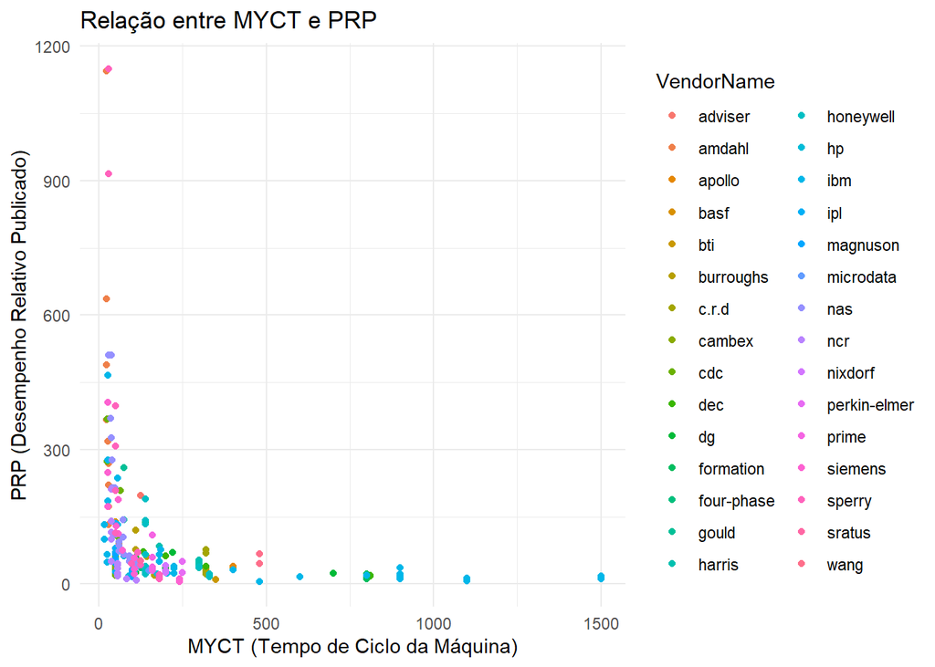

```r
ggplot(computer_data, aes(x = MYCT, y = PRP, color = VendorName)) +
  geom_point() +
  labs(title = "Relação entre MYCT e PRP", x = "MYCT (Tempo de Ciclo da Máquina)", y = "PRP (Desempenho Relativo Publicado)") +
  theme_minimal() +
  theme(legend.position = "right")
```

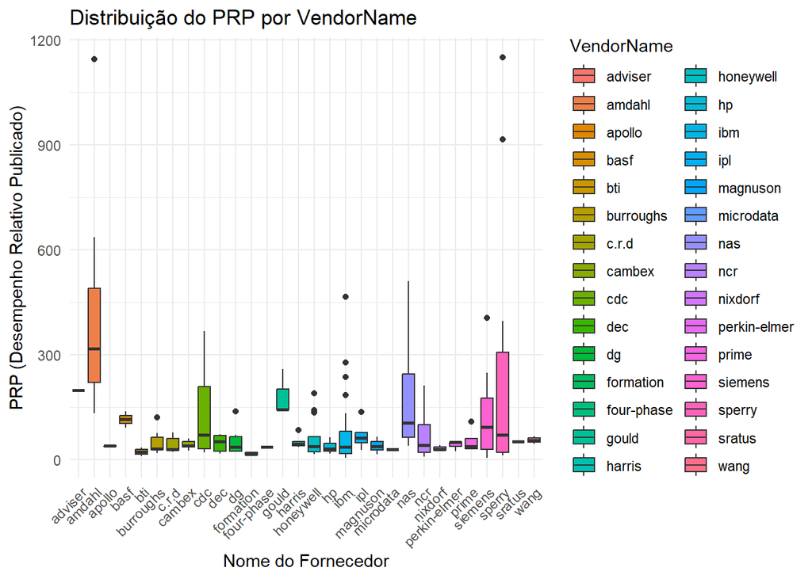

```r
ggplot(computer_data, aes(x = VendorName, y = PRP, fill = VendorName)) +
  geom_boxplot() +
  labs(title = "Distribuição do PRP por VendorName", x = "Nome do Fornecedor", y = "PRP (Desempenho Relativo Publicado)") +
  theme_minimal() +
  theme(axis.text.x = element_text(angle = 45, hjust = 1))  # Rotaciona os rótulos do eixo x
```

## Análise de Correlação

**Descrição:** Para descobrir a correlação entre as variáveis numéricas e a classe dos dados, vou usar a função cor() para calcular a correlação de cada variável com a classe alvo, no meu caso PRP.

```r
numericas <- computer_data[, sapply(computer_data, is.numeric)]

correlacoes <- cor(numericas)

correlacao_com_classe <- correlacoes[, "PRP"]

print(correlacao_com_classe)
```

```
##       MYCT       MMIN       MMAX       CACH      CHMIN      CHMAX        PRP
## -0.3070994  0.7949313  0.8630041  0.6626414  0.6089033  0.6052093  1.0000000
##        ERP
##  0.9664717
```

A análise de correlação revelou que as variáveis MMIN e MMAX apresentam correlações fortes e positivas com o PRP, indicando que um aumento na memória mínima e máxima está associado a um desempenho relativo melhor. A variável CACH também mostrou uma correlação positiva moderada, sugerindo que mais memória cache contribui para um desempenho superior. Em contrapartida, a variável MYCT tem uma correlação negativa com o PRP, o que significa que um tempo de ciclo maior está relacionado a um desempenho inferior. As variáveis CHMIN e CHMAX também mostraram correlações positivas moderadas, sugerindo que mais canais podem melhorar o desempenho. Finalmente, a correlação extremamente forte entre ERP e PRP indica que o desempenho estimado e o publicado estão alinhados, reforçando a consistência das medições de desempenho.

### Pré-processamento e Padrões Esperados

| Artigo | Estatística Descritiva Relatada | Pré-processamento dos Dados | Objetivo da Análise |
| --- | --- | --- | --- |
| **Universum learning for SVM regression** | Apresenta correlações entre variáveis e desempenho do modelo. | Normalização dos dados, tratamento de outliers. | Propor uma nova formulação para problemas de regressão, incorporando amostras Universum para melhorar a precisão do modelo. |
| **A greedy constructive algorithm for the optimization of neural network architectures** | Descrição das variáveis com medidas como média e desvio padrão. | Ajuste nas arquiteturas da rede neural, otimização de hiperparâmetros. | Minimizando a complexidade das arquiteturas de redes neurais sem comprometer o desempenho preditivo. |

Essas informações destacam a relevância da base de dados para a pesquisa em aprendizado de máquina e inteligência artificial, além de sugerir a importância de técnicas de pré-processamento na melhoria da performance dos modelos.